# Guia contraste de hipótesis

Métodos de análisis no paramétricos

Dr. José A. Gallardo.

Profesor adjunto de la Pontificia Universidad Católica de Valparaíso  
jose.gallardo@pucv.cl

May 03, 2021

#### Objetivos de aprendizaje

Realizar e interpretar pruebas de contraste no paramétrico con **software R**.

#### Conceptos importantes

Las pruebas de contraste de hipótesis son procedimientos estadísticos que tienen como propósito evaluar o someter a prueba una hipótesis que formula el investigador.

Para ejecutar una prueba de hipótesis el investigador debe formular una hipótesis nula y otra alternativa.

La hipótesis nula (H0) es una afirmación, usualmente de igualdad, contraria a la hipótesis alternativa (H1).

La hipótesis alternativa es una afirmación que se deduce de una observación previa o de los antecedentes de literatura y que el investigador cree que es verdadera.

**Prueba de Wilkoxon**  
La prueba de Wilcoxon es una prueba no paramétrica que permite comparar dos muestras y determinar si existen diferencias entre ellas. Se utiliza cuando no se puede suponer la normalidad de dichas muestras. Las muestras puedes ser independientes, pareadas o repetidas.

**Prueba de Kurskal Wallis**  
Pa prueba de Kruskal-Wallis es un método no paramétrico que permite evaluar si multiples muesttras independientes provienen de una población común. Comúnmente se utiliza esta prueba como alternativa a un ANOVA cuando los datos no tienen una distribución normal

#### Software.

Esta es la versión de R que se usó para crear esta guía.

```r
R.version.string
```

```
## [1] "R version 4.0.3 (2020-10-10)"
```

#### Librerías.

**{stats}**  
This package contains functions for statistical calculations and random number generation.

**{readxl}**  
Read Excel Files.

#### Comandos para realizar los análisis.

**read_excel()**  
**data.frame()**  
**colnames()**  
**boxplot()**  
**wilcox.test()**  
**kruskal.test()**

#### EJERCICIOS

Realice los ejercicios de forma colaborativa con uno o dos compañeros.

Elabore un archivo Rmarkdown o file con extensión **.Rmd** en Rstudio o Rstudio.cloud y configurelo para exportar el resultado como un documento dinámico **pdf**.

En el primer bloque de códigos o **chunk** configure los comandos de la siguiente manera *knitr::opts_chunk$set(echo = TRUE)* y habilite la librería **stats** y **readxl** usando la función library().

Tabla 1. Abundancia de larvas de peces benticos y pelagicos por 1000 metros cúbicos

| Peces pelágicos | Peces benticos |
| --- | --- |
| 140 | 90 |
| 110 | 120 |
| 120 | 130 |
| 155 | 150 |
| 100 | 100 |

1. Escriba su hipótesis nula y alternativa para este experimento.

```r
# H0 : La abundancia de larvas de peces pelágicos es igual a la abundancia de peces bénticos.
# H1 : La abundancia de larvas de peces pelágicos es mayor a la abundancia de peces bénticos.
```

2. Cree un data.frame con la abundancia de larvas de peces pelágicos y benticos.

```r
# Crea objetos PB y PP
PP <- c(140, 110, 120, 155, 100)
PB <- c(90, 120, 130, 150, 100)


larvas <- data.frame(PP, PB)

colnames(larvas) <- c("Peces pelágicos", "Peces benticos")
larvas
```

```
##   Peces pelágicos Peces benticos
## 1             140             90
## 2             110            120
## 3             120            130
## 4             155            150
## 5             100            100
```

```r
class(larvas)
```

```
## [1] "data.frame"
```

3. Elabore un boxplot para comparar la abundancia de larvas entre peces pelágicos y bentónicos, use la función **boxplot()**

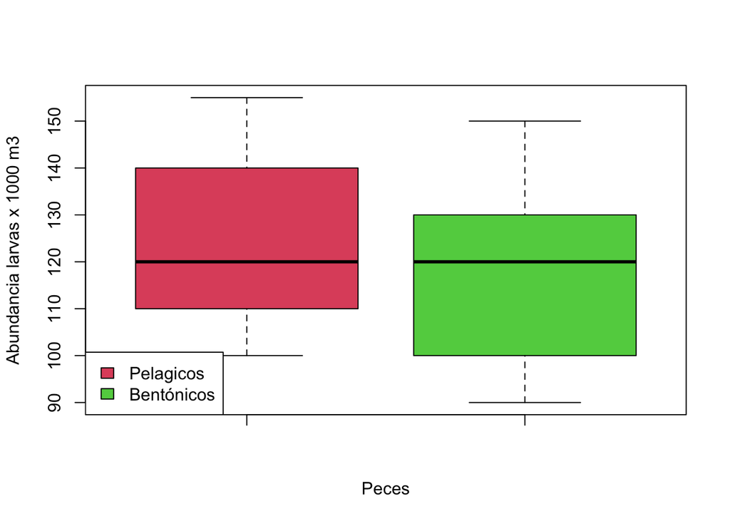

```r
boxplot(larvas$`Peces pelágicos`, larvas$`Peces benticos` , col=c(2,3), ylab= "Abundancia larvas x 1000 m3", xlab= "Peces")
legend("bottomleft",
       legend = c("Pelagicos", "Bentónicos"),
       fill = 2:3,       # Color de los rectángulos
       border = "black") # Color del borde de los rectángulos
```

4. Ponga a prueba su hipótesis usando el test de wilcoxon usando la función **wilcox.test()**, no olvide seleccionar en el argumento *alternative=""* para indicar que hipótesis evaluará *“two.sided”*, *“less”*, *“greater”*. También incluya el argumento *paired = FALSE*.

```r
# Prueba de Wilcoxon en R (wilcox.test)
wilcox.test(PP, PB, alternative = "g", paired = FALSE)
```

```
##
##  Wilcoxon rank sum test with continuity correction
##
## data:  PP and PB
## W = 15, p-value = 0.3371
## alternative hypothesis: true location shift is greater than 0
```

5. Interprete sus resultados.